# This is a national broadcasted tutorial presented to you by

# Linear Regression Model

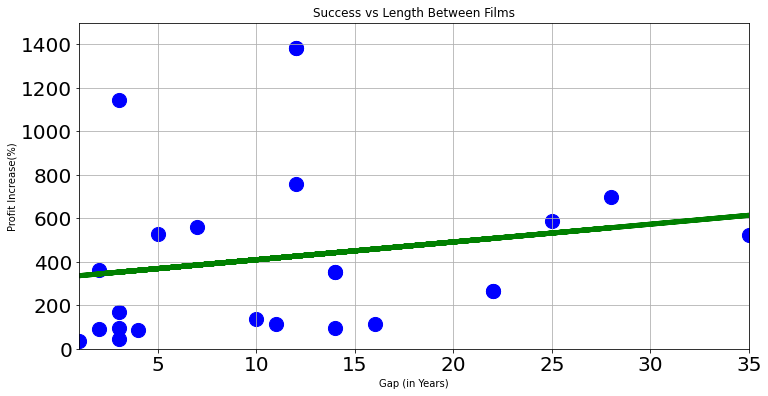

```python
regr = lm.LinearRegression()
y = np.array(y_list)
y = y.reshape(-1,1)
x = np.array(x_list)
x = x.reshape(-1,1)
lr = regr.fit(x,y)
intercept = lr.intercept_
slope = lr.coef_
y = (intercept + slope*x).reshape(24,)
fig = plt.figure(figsize=(12,6))
plt.plot(x,y,'green', linewidth=5,
         data = plot1.plot(x='Gap (in Years)',y='Profit Increase(%)', kind="scatter",figsize=(12,6),
                           s=200, title='Success vs Length Between Films', color='blue',fontsize=20))
plt.xlabel('Gap (in Years)')
plt.ylabel('Profit Increase(%)')
plt.ylim(0,1500)
plt.xlim(1,35)
plt.grid()
plt.show()
```

- The green line is the Linear Regression and the scatterplot shows the sequels with the x axis showing the gap in between the first and latest sequel. The y-axis shows the profit margin increase of the sequels.
- Since the LR is a positive slope, the LR suggests that the longer you wait the more likely that the movies are going to improve even though our intuition would tell us otherwise.
- # Data Mining/Collection
- Getting the data from "https://www.thewrap.com/32-movie-sequels-took-forever-long-delay-blade-runner/" and putting the data in a table to manipulate

```python
site = requests.get(s1)
string = site.text

movies_raw = string.split("<strong>")#viewing the html string, this gives us a good enough
# start to separate the items.
movies_raw.pop(0) #removes the prologue
movies_raw.pop() #removes the extra text at the end (including Bill&Ted info))
cols = ['Title','year','Predecessor','Pred. year']
data = [['Bill & Ted Face the Music'],['2020'],["\"Bill & Ted's Bogus Journey\""],['1991']]

# Retrieving the sequel title and year
for i in range(len(movies_raw)):
    title=re.search("(\"[a-zA-Z0-9\s:]+\")", movies_raw[i]).group(0)
    year=re.search("[12][0-9]{3}",movies_raw[i]).group(0)
    data[0].append(title)
    data[1].append(year)


# Sometimes Webscrapping can be uncooperative so the easiest thing to do is hardcode it. For a list of
# less than 40 items it isn't too time-consuming.
Pred = [('Psycho', '1960'),('The Hustler', '1961'),('Texas Chainsaw Massacre','1974'),
        ('Chinatown', '1974'),('The Last Picture Show','1971'),('The Godfather Part II','1974'),
        ('The Odd Couple','1968'),('Blues Brothers','1980'),('Crocodile Dundee II','1988'),
        ('Clerks','1992'),('Rocky V','1990'),('Basic Instinct','1992'),('Die Hard with a Vengeance','1995'),
        ('Tron','1982'),('Wall Street','1987'),('The Best Man','1999'),('Dumb and Dumber','1994'),
        ('Jurrasic Park III','2001'),('Mad Max Beyond ThunderDome','1985'),('Independence Day','1996'),
        ('GhostBusters','1989'), ('My Big Fat Greek Wedding','2002'),('Zoolander','2001'),
        ('Bridget Jones: The Edge of Reason','2004'),('Finding Nemo','2003'),('BarberShop: Back in Business','2004'),
        ('Trainspotting','1996'), ('BladeRunner 2049','1982'),('XXX: State of the Union', '2005'),
        ('Super Trooper', '2001'),('Incredibles','2004'),('**Unbreakable','2000'),
        ('Rambo III','1999'),('Bad Boys II', '2003')
       ]

for (title,year) in Pred:
    data[2].append(f"\"{title}\"")
    data[3].append(year)

# Builing the table using the site data
table1 = pd.DataFrame(columns=cols)
table1['Title']=data[0]
table1['year']=data[1]
table1['Predecessor']=data[2]
table1['Pred. year']=data[3]

diff = []
for (idx,row) in table1.iterrows():
    diff.append(int(row['year']) - int(row['Pred. year']))

table1["Gap (in Years)"] = diff
table1#.drop(columns="Predecessor year")
```

|  | Title | year | Predecessor | Pred. year | Gap (in Years) |
| --- | --- | --- | --- | --- | --- |
| 0 | Bill & Ted Face the Music | 2020 | "Bill & Ted's Bogus Journey" | 1991 | 29 |
| 1 | "Psycho II" | 1983 | "Psycho" | 1960 | 23 |
| 2 | "The Color of Money" | 1986 | "The Hustler" | 1961 | 25 |
| 3 | "The Texas Chainsaw Massacre 2" | 1986 | "Texas Chainsaw Massacre" | 1974 | 12 |
| 4 | "The Two Jakes" | 1990 | "Chinatown" | 1974 | 16 |
| 5 | "Texasville" | 1990 | "The Last Picture Show" | 1971 | 19 |
| 6 | "The Godfather Part III" | 1990 | "The Godfather Part II" | 1974 | 16 |
| 7 | "The Odd Couple II" | 1998 | "The Odd Couple" | 1968 | 30 |
| 8 | "Blues Brothers 2000" | 2000 | "Blues Brothers" | 1980 | 20 |
| 9 | "Crocodile Dundee in Los Angeles" | 2001 | "Crocodile Dundee II" | 1988 | 13 |
| 10 | "Clerks 2" | 2004 | "Clerks" | 1992 | 12 |
| 11 | "Rocky Balboa" | 2006 | "Rocky V" | 1990 | 16 |
| 12 | "Basic Instinct 2" | 2006 | "Basic Instinct" | 1992 | 14 |
| 13 | "Live Free or Die Hard" | 2007 | "Die Hard with a Vengeance" | 1995 | 12 |
| 14 | "Tron: Legacy" | 2010 | "Tron" | 1982 | 28 |
| 15 | "Wall Street: Money Never Sleeps" | 2010 | "Wall Street" | 1987 | 23 |
| 16 | "The Best Man Holiday" | 2013 | "The Best Man" | 1999 | 14 |
| 17 | "Dumb and Dumber To" | 2014 | "Dumb and Dumber" | 1994 | 20 |
| 18 | "Jurassic World" | 2015 | "Jurrasic Park III" | 2001 | 14 |
| 19 | "Mad Max: Fury Road" | 2015 | "Mad Max Beyond ThunderDome" | 1985 | 30 |
| 20 | "Independence Day: Resurgence" | 2016 | "Independence Day" | 1996 | 20 |
| 21 | "Ghostbusters" | 2016 | "GhostBusters" | 1989 | 27 |
| 22 | "My Big Fat Greek Wedding 2" | 2016 | "My Big Fat Greek Wedding" | 2002 | 14 |
| 23 | "Zoolander 2" | 2016 | "Zoolander" | 2001 | 15 |
| 24 | "Finding Dory pixar" | 2016 | "Bridget Jones: The Edge of Reason" | 2004 | 12 |
| 25 | "Finding Dory" | 2016 | "Finding Nemo" | 2003 | 13 |
| 26 | "Barbershop: The Next Cut" | 2016 | "BarberShop: Back in Business" | 2004 | 12 |
| 27 | "T2 Trainspotting" | 2017 | "Trainspotting" | 1996 | 21 |
| 28 | "Blade Runner 2049" | 2049 | "BladeRunner 2049" | 1982 | 67 |
| 29 | "xXx: Return of Xander Cage" | 2017 | "XXX: State of the Union" | 2005 | 12 |
| 30 | "Super Troopers 2" | 2018 | "Super Trooper" | 2001 | 17 |
| 31 | "Incredibles 2" | 2018 | "Incredibles" | 2004 | 14 |
| 32 | "Glass" | 2019 | "**Unbreakable" | 2000 | 19 |
| 33 | "Rambo: Last Blood" | 2019 | "Rambo III" | 1999 | 20 |
| 34 | "Bad Boys For Life" | 2020 | "Bad Boys II" | 2003 | 17 |

# WorldWide BoxOffice Sequels

- for this section of the code... we will be scraping the data from the_numbers.com and manipulating the recived data so that we can put it in a pandas table and perform some calculations.

```python
r = requests.get('https://www.the-numbers.com/box-office-records/worldwide/all-movies/cumulative/sequel')
soup = BeautifulSoup(r.content)
col = soup.find('table')
the = col.tbody.text
split = the.split("\n\n")

array = []
for i in range(len(split)):
    if split[i] != '':
        array.append(split[i].split("\n"))

for i in range(len(array)):
    if array[i][0] == '':
        array[i].remove('')
# putting on the table


table = pd.DataFrame(data = array, columns = ["Rank","Released","Movie","Worldwide Box Office","Domestic Box Office","International Box Office"])
n = table.sort_values(by = 'Movie')
# we removed data from the top 100 that did not have a sequel
updated_table = n.drop(index = [46,98,95,71,62,85,27,5,47,91,10,61,81,92,80,83,68,96,17,44,74,11,97,69,66,52,75])
updated_table.Movie[88] = 'Fast and Furious 5'
updated_table.Movie[4] = 'Fast and Furious 7'
updated_table
```

|  | Rank | Released | Movie | Worldwide Box Office | Domestic Box Office | International Box Office |
| --- | --- | --- | --- | --- | --- | --- |
| 89 | 89 | 2018 | Ant-Man and the Wasp | $623,144,660 | $216,648,740 | $406,495,920 |
| 6 | 7 | 2015 | Avengers: Age of Ultron | $1,395,316,979 | $459,005,868 | $936,311,111 |
| 0 | 1 | 2019 | Avengers: Endgame | $2,797,800,564 | $858,373,000 | $1,939,427,564 |
| 2 | 3 | 2018 | Avengers: Infinity War | $2,044,540,523 | $678,815,482 | $1,365,725,041 |
| 13 | 14 | 2016 | Captain America: Civil War | $1,151,918,521 | $408,084,349 | $743,834,172 |
| ... | ... | ... | ... | ... | ... | ... |
| 20 | 21 | 2019 | Toy Story 4 | $1,073,080,329 | $434,038,008 | $639,042,321 |
| 18 | 19 | 2014 | Transformers: Age of Extinction | $1,104,054,072 | $245,439,076 | $858,614,996 |
| 15 | 16 | 2011 | Transformers: Dark of the Moon | $1,123,794,079 | $352,390,543 | $771,403,536 |
| 51 | 52 | 2009 | Transformers: Revenge of the Fallen | $836,519,699 | $402,111,870 | $434,407,829 |
| 93 | 93 | 2017 | Transformers: The Last Knight | $602,893,340 | $130,168,683 | $472,724,657 |

74 rows × 6 columns

- So now that we have out data, we need to separate our data from our sequels and our non sequels, which we have done with the code provided above. In this table we can see movies that dont have sequels or are not present in the table, so we removed them.
- On our next step we will be calcualting difference in the year, difference between the Box Office amount, and also calculating the percent difference between the original movie and the latest sequel.
- Then put these new calculations into a new datatable.

```python
# all the sequels in this table
Sequels = ['Avengers','Captain America','Despicable Me','Fast and Furious','Harry Potter','Ice Age','Iron Man','Jumanji','Jurassic World','Madagascar','Mission: impossible','Shrek','Spider-Man','Star Wars','The Amazing Spider-man','Dark Knight','The Hobbit','The Hunger Games','The Lord of the Rings','The Twilight Saga','Thor','Toy Story','Transformers']

#this is calculating the differenc between year and in boxoffice amount of the different sequels
year_diff = []
amount_diff = []
each_movie_percent = []
num_of_sequels = []

# this is running through the sequels and calulating year, amount, and precent
for i in Sequels:

    each_movie_table = updated_table[updated_table['Movie'].str.contains(i, regex=False, case=False, na=False)]
    num_of_sequels.append(len(each_movie_table.Movie))
    each_movie_table = each_movie_table.sort_values(by = "Released")

    each_movie = each_movie_table.Released
    each_movie_money =  each_movie_table['Worldwide Box Office']
    #removing the $ and the , so that i can change into an int
    each_movie_money = each_movie_money.str.replace(r'$', '')
    each_movie_money = each_movie_money.str.replace(r',','')

    size = len(each_movie_table)
    #print(int(np.array(each_movie)[size-1]))
    #print(int(np.array(each_movie)[size-size]))

    year_diff.append(abs(int(np.array(each_movie)[size-1]) - int(np.array(each_movie)[size-size])))
    amount_diff.append(abs(int(np.array(each_movie_money)[size-1]) - int(np.array(each_movie_money)[size-size])))
    each_movie_percent.append(round((abs(int(np.array(each_movie_money)[size-1]) - int(np.array(each_movie_money)[size-size]))/int(np.array(each_movie_money)[size-1])),3)*100)


#putting the new values into a table
Seq_diff = pd.DataFrame(data = [], columns = ["Movie","# of Sequels","Next/last Sequel..Year Diff","Diff in sequence amount","Perc"])
Seq_diff["Movie"] = Sequels
Seq_diff["Next/last Sequel..Year Diff"] = year_diff
Seq_diff["Diff in sequence amount"] = amount_diff
Seq_diff["Perc"] = each_movie_percent
Seq_diff['# of Sequels'] = num_of_sequels
Seq_diff
```

|  | Movie | # of Sequels | Next/last Sequel..Year Diff | Diff in sequence amount | Perc |
| --- | --- | --- | --- | --- | --- |
| 0 | Avengers | 3 | 4 | 1402483585 | 50.1 |
| 1 | Captain America | 2 | 2 | 437516632 | 38.0 |
| 2 | Despicable Me | 2 | 4 | 57380059 | 5.6 |
| 3 | Fast and Furious | 3 | 4 | 887016255 | 58.5 |
| 4 | Harry Potter | 7 | 9 | 457883739 | 34.3 |
| 5 | Ice Age | 3 | 6 | 227865855 | 25.9 |
| 6 | Iron Man | 2 | 3 | 594235883 | 48.9 |
| 7 | Jumanji | 2 | 2 | 161411570 | 20.2 |
| 8 | Jurassic World | 2 | 3 | 361645962 | 27.6 |
| 9 | Madagascar | 2 | 4 | 147240497 | 19.7 |
| 10 | Mission: impossible | 4 | 18 | 237588213 | 30.2 |
| 11 | Shrek | 3 | 6 | 179009305 | 23.7 |
| 12 | Spider-Man | 5 | 15 | 336522088 | 29.7 |
| 13 | Star Wars | 7 | 39 | 523942980 | 48.8 |
| 14 | The Amazing Spider-man | 2 | 2 | 48893931 | 6.9 |
| 15 | Dark Knight | 2 | 4 | 83181826 | 7.7 |
| 16 | The Hobbit | 3 | 2 | 73674663 | 7.8 |
| 17 | The Hunger Games | 3 | 2 | 215881260 | 33.3 |
| 18 | The Lord of the Rings | 2 | 1 | 201075282 | 17.9 |
| 19 | The Twilight Saga | 4 | 3 | 142167010 | 17.1 |
| 20 | Thor | 2 | 4 | 205880262 | 24.2 |
| 21 | Toy Story | 2 | 9 | 4200807 | 0.4 |
| 22 | Transformers | 4 | 8 | 233626359 | 38.8 |

- splitting the data into early and late sequels.
- we are defining a "late" sequel as being a movie that takes over 7 years inbetweeen. a
- And a "early" sequel being within the first 7 years.
- when looking at the data table we can see that there are more early sequels when compared to the later sequels. One early hypothesis would be that keeping the release of a movie within the first 7 years has the perfect blend of anticipation without the hype for the movie dying.

```python
#separating the table by early sequence

early_sequels = Seq_diff[Seq_diff["Next/last Sequel..Year Diff"] <= 7 ]
early_sequels = early_sequels.sort_values(by = "Diff in sequence amount")
early_sequels
```

|  | Movie | # of Sequels | Next/last Sequel..Year Diff | Diff in sequence amount | Perc |
| --- | --- | --- | --- | --- | --- |
| 14 | The Amazing Spider-man | 2 | 2 | 48893931 | 6.9 |
| 2 | Despicable Me | 2 | 4 | 57380059 | 5.6 |
| 16 | The Hobbit | 3 | 2 | 73674663 | 7.8 |
| 15 | Dark Knight | 2 | 4 | 83181826 | 7.7 |
| 19 | The Twilight Saga | 4 | 3 | 142167010 | 17.1 |
| 9 | Madagascar | 2 | 4 | 147240497 | 19.7 |
| 7 | Jumanji | 2 | 2 | 161411570 | 20.2 |
| 11 | Shrek | 3 | 6 | 179009305 | 23.7 |
| 18 | The Lord of the Rings | 2 | 1 | 201075282 | 17.9 |
| 20 | Thor | 2 | 4 | 205880262 | 24.2 |
| 17 | The Hunger Games | 3 | 2 | 215881260 | 33.3 |
| 5 | Ice Age | 3 | 6 | 227865855 | 25.9 |
| 8 | Jurassic World | 2 | 3 | 361645962 | 27.6 |
| 1 | Captain America | 2 | 2 | 437516632 | 38.0 |
| 6 | Iron Man | 2 | 3 | 594235883 | 48.9 |
| 3 | Fast and Furious | 3 | 4 | 887016255 | 58.5 |
| 0 | Avengers | 3 | 4 | 1402483585 | 50.1 |

```python
#Separating by late sequel
late_sequels = Seq_diff[Seq_diff["Next/last Sequel..Year Diff"] > 7 ]
late_sequels = late_sequels.sort_values(by = "Diff in sequence amount")
late_sequels
```

|  | Movie | # of Sequels | Next/last Sequel..Year Diff | Diff in sequence amount | Perc |
| --- | --- | --- | --- | --- | --- |
| 21 | Toy Story | 2 | 9 | 4200807 | 0.4 |
| 22 | Transformers | 4 | 8 | 233626359 | 38.8 |
| 10 | Mission: impossible | 4 | 18 | 237588213 | 30.2 |
| 12 | Spider-Man | 5 | 15 | 336522088 | 29.7 |
| 4 | Harry Potter | 7 | 9 | 457883739 | 34.3 |
| 13 | Star Wars | 7 | 39 | 523942980 | 48.8 |

```
<function matplotlib.pyplot.show(close=None, block=None)>
```

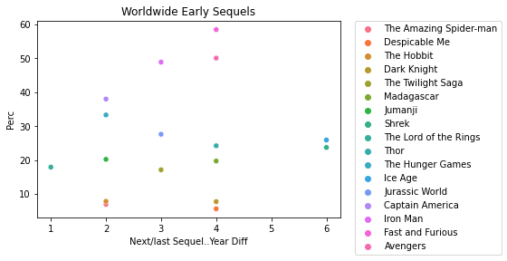

```python
c = sns.scatterplot(data=early_sequels, x="Next/last Sequel..Year Diff", y="Perc",hue = "Movie")

plt.title('Worldwide Early Sequels')
plt.legend(bbox_to_anchor=(1.05, 1), loc=2, borderaxespad=0.)

plt.show
```

```
<function matplotlib.pyplot.show(close=None, block=None)>
```

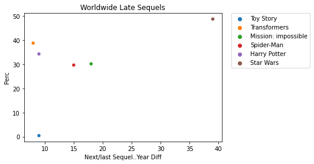

```python
sns.scatterplot(data=late_sequels, x="Next/last Sequel..Year Diff", y="Perc",hue = "Movie")
plt.title('Worldwide Late Sequels')
plt.legend(bbox_to_anchor=(1.05, 1), loc=2, borderaxespad=0.)
plt.show
```

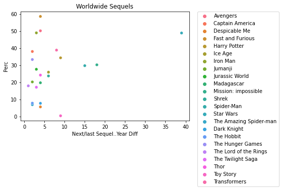

```python
ax = sns.scatterplot(data=Seq_diff, x="Next/last Sequel..Year Diff", y="Perc",hue = "Movie")
plt.title('Worldwide Sequels')
plt.legend(bbox_to_anchor=(1.05, 1), loc=2, borderaxespad=0.)
plt.show()
```

# Linear Regression for WorldWide Sequels

- This is a linear regression plot for the WorldWide Sequels shown above
- for the sake of the Linear Regression, removed the outlier (Starwars)

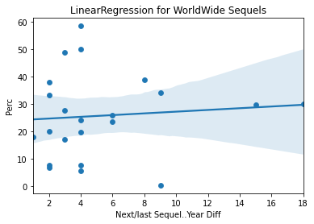

```python
Seq_diff.drop(index = 13,inplace = True)
ax = sns.scatterplot(data=Seq_diff, x="Next/last Sequel..Year Diff", y="Perc")
sns.regplot(data=Seq_diff, x="Next/last Sequel..Year Diff", y="Perc", ax=ax)
plt.title("LinearRegression for WorldWide Sequels")
```

# Differences between Franchise and time period.

# Marvel

[figure not shown]

```python
r = requests.get('https://www.boxofficemojo.com/franchise/fr4148662021/?ref_=bo_frs_table_1')
soup = BeautifulSoup(r.content)
col = soup.find('table')
opening = col.find_all('td',class_ = 'a-text-right mojo-field-type-money')
lifetime = col.find_all('td',class_ = 'a-text-right mojo-field-type-money mojo-sort-column mojo-estimatable')
names = col.find_all('td',class_ = 'a-text-left mojo-field-type-release mojo-cell-wide')
dates = col.find_all('td',class_ = 'a-text-left mojo-field-type-date a-nowrap')

name = []
life = []
opn = []
date = []
for i in names:
    name.append(i.text)
for i in lifetime:
    life.append(i.text)
for i in opening:
    opn.append(i.text)
for i in dates:
    date.append(i.text)

table = pd.DataFrame(data = [], columns = ["name","Date","open","life"])
table["name"] = name
table["open"] = life
table["life"] = opn
table["Date"] = date
table = table.drop([36,26,28,35,30,32,27,34,29,31,37,33,25,24,23])
new_table = table.drop
table.Date = pd.to_datetime(table.Date)
table = table.sort_values(by = "Date")

b = table.open
b = b.str.replace(r'$','')
b = b.str.replace(r',','')
a = np.array(b)
Diff_array = []
per_array = []
Diff_array.append(int(a[len(a)-1]) - int(a[0]))
num1 = int(a[len(a)-1])
num2 = int(a[0])
per_array.append(round(((num1 - num2)/num1) *100,3))
table
```

|  | name | Date | open | life |
| --- | --- | --- | --- | --- |
| 12 | Iron Man | 2008-05-02 | $318,604,126 | $98,618,668 |
| 22 | The Incredible Hulk | 2008-06-13 | $134,806,913 | $55,414,050 |
| 14 | Iron Man 2 | 2010-05-07 | $312,433,331 | $128,122,480 |
| 19 | Thor | 2011-05-06 | $181,030,624 | $65,723,338 |
| 21 | Captain America: The First Avenger | 2011-07-22 | $176,654,505 | $65,058,524 |
| 3 | The Avengers | 2012-05-04 | $623,357,910 | $207,438,708 |
| 6 | Iron Man 3 | 2013-05-03 | $409,013,994 | $174,144,585 |
| 18 | Thor: The Dark World | 2013-11-08 | $206,362,140 | $85,737,841 |
| 15 | Captain America: The Winter Soldier | 2014-04-04 | $259,766,572 | $95,023,721 |
| 11 | Guardians of the Galaxy | 2014-08-01 | $333,176,600 | $94,320,883 |
| 4 | Avengers: Age of Ultron | 2015-05-01 | $459,005,868 | $191,271,109 |
| 20 | Ant-Man | 2015-07-17 | $180,202,163 | $57,225,526 |
| 7 | Captain America: Civil War | 2016-05-06 | $408,084,349 | $179,139,142 |
| 16 | Doctor Strange | 2016-11-04 | $232,641,920 | $85,058,311 |
| 9 | Guardians of the Galaxy Vol. 2 | 2017-05-05 | $389,813,101 | $146,510,104 |
| 10 | Spider-Man: Homecoming | 2017-07-07 | $334,201,140 | $117,027,503 |
| 13 | Thor: Ragnarok | 2017-11-03 | $315,058,289 | $122,744,989 |
| 1 | Black Panther | 2018-02-16 | $700,059,566 | $202,003,951 |
| 2 | Avengers: Infinity War | 2018-04-27 | $678,815,482 | $257,698,183 |
| 17 | Ant-Man and the Wasp | 2018-07-06 | $216,648,740 | $75,812,205 |
| 5 | Captain Marvel | 2019-03-08 | $426,829,839 | $153,433,423 |
| 0 | Avengers: Endgame | 2019-04-26 | $858,373,000 | $357,115,007 |
| 8 | Spider-Man: Far from Home | 2019-07-02 | $390,532,085 | $92,579,212 |

# Franchise X-Men

[figure not shown]

```python
r = requests.get('https://www.boxofficemojo.com/franchise/fr3712454405/?ref_=bo_frs_table_6')
soup = BeautifulSoup(r.content)
col = soup.find('table')
opening = col.find_all('td',class_ = 'a-text-right mojo-field-type-money')
lifetime = col.find_all('td',class_ = 'a-text-right mojo-field-type-money mojo-sort-column mojo-estimatable')
names = col.find_all('td',class_ = 'a-text-left mojo-field-type-release mojo-cell-wide')
dates = col.find_all('td',class_ = 'a-text-left mojo-field-type-date a-nowrap')

name = []
life = []
opn = []
date = []
for i in names:
    name.append(i.text)
for i in lifetime:
    life.append(i.text)
for i in opening:
    opn.append(i.text)
for i in dates:
    date.append(i.text)

table = pd.DataFrame(data = [], columns = ["name","Date","open","life"])
table["name"] = name
table["open"] = life
table["life"] = opn
table["Date"] = date
table.Date = pd.to_datetime(table.Date)
table = table.sort_values(by = "Date")
table
```

|  | name | Date | open | life |
| --- | --- | --- | --- | --- |
| 7 | X-Men | 2000-07-14 | $157,299,718 | $54,471,475 |
| 5 | X2: X-Men United | 2003-05-02 | $214,949,694 | $85,558,731 |
| 2 | X-Men: The Last Stand | 2006-05-26 | $234,362,462 | $102,750,665 |
| 6 | X-Men Origins: Wolverine | 2009-05-01 | $179,883,157 | $85,058,003 |
| 9 | X-Men: First Class | 2011-06-03 | $146,408,305 | $55,101,604 |
| 10 | The Wolverine | 2013-07-26 | $132,556,852 | $53,113,752 |
| 3 | X-Men: Days of Future Past | 2014-05-23 | $233,921,534 | $90,823,660 |
| 0 | Deadpool | 2016-02-12 | $363,070,709 | $132,434,639 |
| 8 | X-Men: Apocalypse | 2016-05-27 | $155,442,489 | $65,769,562 |
| 4 | Logan | 2017-03-03 | $226,277,068 | $88,411,916 |
| 1 | Deadpool 2 | 2018-05-18 | $318,491,426 | $125,507,153 |
| 13 | Once Upon a Deadpool2018 Re-release | 2018-12-12 | $6,100,309 | $2,683,200 |
| 11 | X-Men: Dark Phoenix | 2019-06-07 | $65,845,974 | $32,828,348 |
| 12 | The New Mutants | 2020-08-28 | $23,852,659 | $7,037,017 |

```python
b = table.open
b = b.str.replace(r'$','')
b = b.str.replace(r',','')
a = np.array(b)
Diff_array.append(abs(int(a[len(a)-1]) - int(a[0])))
num1 = int(a[len(a)-1])
num2 = int(a[0])
per_array.append(round(((num2 - num1)/num2) *100,3))
```